# Part III: GLMGA regression models

Zhengxiao Li , Jan Beirlant, Shengwang Meng

This is an *R code* and *data-set* for the paper “**Generalizing the log-Moyal distribution and regression models for heavy tailed loss data**”. When you execute code within the notebook, the results appear beneath the code.

## Loading the packages used in this paper

```r
# loading the packages used in this paper
path.file <- getwd()
setwd(path.file)
source('0. definition of logmoyal distribution.r', local = T)
source('0. definition of logmoyal-gamma distribution.r', local = T)
source('0. definition of log-gamma distribution.r', local = T)
source('0. definition of DPLN distribution.r', local = T)
library(gamlss)
library(data.table)
library(actuar)
library(cowplot)
library(latex2exp)
library(ggplot2)
library(extRemes)
library(qqplotr)
library(fitdistrplus)
library(SMPracticals)
library(moments)
library(knitr)
library(ReIns)
library(qqplotr)
library(ggsci)
library(patchwork)
library(RColorBrewer)
library(POT)
```

## Application of the GLMGA regression to earthquake losses data set

- Descriptive analysis
- *ynew*: Economic Losses (adjusted by the CPI index)
- *y*: Economic Losses (original)
- *death*: the number of deaths from an earthquakic event
- *inj*: the number of injures from an earthquakic event
- *hour*, *min*, *time*: the exact time of an first earthquakic event
- *magnitude*, *intensity* : the magnitude and maximunintensity of an earthquakic event

```r
# ---------------------------------------------------------
# difine the hessian matrix output and the stardard error -------------------
# ---------------------------------------------------------
modout <- function(m) {
  Hessian <- m$hessian
  se <- sqrt(diag(solve(Hessian)))                  ## stardard error
  Z <- m$par/se                                             ##  Z statistic
  p <- ifelse(Z>=0, pnorm(Z, lower=F)*2, pnorm(Z)*2)           ## p value
  summarytable <- round(data.frame(m$par, se, Z, p), 3)
  NLL <- m$value  # - loglikelihood value
  AIC <- 2*length(m$par) + 2*NLL
  BIC <- log(length(y))*length(m$par) + 2*NLL
  list(summary = summarytable, ll =  - m$value, AIC = AIC, BIC = BIC)
}
```

### Table 1: Major Chinese earthquakes since 1990.

```r
# read data set from local disk
dtnew <- fread('eqdata.csv', header = T)
dt.order <- dtnew[order(y, decreasing = F)]
tail(dt.order, 20)
```

```
##      V1 year       ynew          y death    inj magnitude intensity location
##  1: 267 2013   2034.152   1966.700     3     63       5.9         8     云南
##  2: 251 2012   2112.205   1990.321     0     52       6.6         8     新疆
##  3: 268 2013   2092.383   2023.000     0     25       5.5         7     吉林
##  4: 184 2005   2701.568   2037.594    13    775       5.7         7     江西
##  5: 219 2009   2553.258   2154.000     1    372       6.0         8     云南
##  6: 280 2014   2409.897   2376.600     1     22       5.9         8     云南
##  7: 232 2011   2596.688   2384.800    25    314       5.8         7     云南
##  8:  66 1996   3577.576   2500.000   309  17057       7.0         6     云南
##  9: 266 2013   2799.987   2707.140     0     87       6.1         8     西藏
## 10: 279 2014   4291.058   4231.770     5     78       6.3         8     四川
## 11: 208 2008   5251.468   4461.870    41   1010       6.1         8     四川
## 12: 254 2012   5063.212   4771.040    81    834       5.7         8     云南
## 13: 277 2014   5181.795   5110.200     1    331       6.6         8     云南
## 14: 290 2015   5430.000   5430.000     3    260       6.5         8     新疆
```

[output cut: 27 more lines]

### Table 2: Distribution of the total economic damage as a function of time.

```r
dtnew$N <- 1
dtnew[, year10 := cut(year, breaks = 5)]
dt.T <- dtnew[,.(year10 = max(year),N.T = sum(N),
                 Mean = mean(ynew),
                 Standard_Deviation = sd(ynew),
                 Median = quantile(ynew, 0.5),
                 Kurtosis = kurtosis(ynew),
                 Skewness = skewness(ynew))]
dt.year <- dtnew[,.(N.T = sum(N),
                    Mean = mean(ynew),
                    Standard_Deviation = sd(ynew),
                    Median = quantile(ynew, 0.5),
                    Kurtosis = kurtosis(ynew),
                  Skewness = skewness(ynew)),
                  by = 'year10']
dt.year <- rbind(dt.year, dt.T)
kable(dt.year)
```

| year10 | N.T | Mean | Standard_Deviation | Median | Kurtosis | Skewness |
| --- | --- | --- | --- | --- | --- | --- |
| (1990,1995] | 63 | 111.4404 | 205.4785 | 25.90553 | 15.70670 | 3.281498 |
| (1995,2000] | 61 | 222.4429 | 572.6679 | 44.07574 | 22.68392 | 4.264993 |
| (2000,2005] | 60 | 226.6849 | 462.7793 | 55.22627 | 17.88012 | 3.690636 |
| (2005,2010] | 46 | 22542.9430 | 146569.1808 | 77.72917 | 43.95938 | 6.551900 |
| (2010,2015] | 61 | 2826.5628 | 9608.4347 | 242.00000 | 38.34125 | 5.743803 |
| 2015 | 291 | 4273.4934 | 58452.5780 | 67.79394 | 285.17992 | 16.806692 |

### Table 3: Distribution of the total economic damage as a function of magnitude

```r
dtnew$N <- 1
dtnew[, magnitude.f := cut(magnitude, breaks = c(3.9, 5.2, 6, 9))]
dt.T <- dtnew[,.(magnitude.f = 'Total', N.T = sum(N),
                 Mean = mean(ynew),
                 Standard_Deviation = sd(ynew),
                 Median = quantile(ynew, 0.5),
                 Kurtosis = kurtosis(ynew),
                 Skewness = skewness(ynew))]
dt.magnitude <- dtnew[,.(N.T = sum(N),
                    Mean = mean(ynew),
                    Standard_Deviation = sd(ynew),
                    Median = quantile(ynew, 0.5),
                    Kurtosis = kurtosis(ynew),
                  Skewness = skewness(ynew)),
                  by = 'magnitude.f']
dt.magnitude <- rbind(dt.magnitude, dt.T)
kable(dt.magnitude)
```

| magnitude.f | N.T | Mean | Standard_Deviation | Median | Kurtosis | Skewness |
| --- | --- | --- | --- | --- | --- | --- |
| (6,9] | 65 | 18441.74411 | 123363.05023 | 367.59561 | 62.232377 | 7.801681 |
| (3.9,5.2] | 123 | 76.63318 | 98.43445 | 31.22508 | 5.374397 | 1.758878 |
| (5.2,6] | 103 | 344.14875 | 752.87495 | 60.88895 | 18.960717 | 3.694493 |
| Total | 291 | 4273.49337 | 58452.57801 | 67.79394 | 285.179924 | 16.806692 |

### Figure 9: Pareto QQ-plots of economic losses for different intervals of magnitude levels.

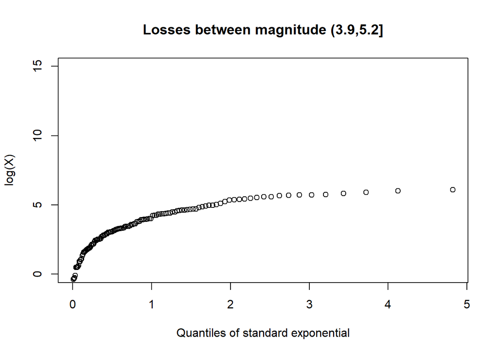

```r
# Pareto QQ-plot
par(mfrow = c(1, 1))

dtnew[, magnitude.f := cut(magnitude, breaks = c(3.9, 5.2, 6, 9))]
dtnew1 <- dtnew[magnitude.f == levels(magnitude.f)[1]]
dtnew2 <- dtnew[magnitude.f == levels(magnitude.f)[2]]
dtnew3 <- dtnew[magnitude.f == levels(magnitude.f)[3]]

m1 <- ParetoQQ(dtnew1$ynew, ylim = c(0, 15),
               main = paste('Losses between magnitude', levels(dtnew$magnitude.f)[1]))
```

```r
m2 <- ParetoQQ(dtnew2$ynew, ylim = c(0, 15), main = paste('Losses between magnitude', levels(dtnew$magnitude.f)[2]))
```

[figure not shown]

```r
m3 <- ParetoQQ(dtnew3$ynew, ylim = c(0, 15), main = paste('Losses between magnitude', levels(dtnew$magnitude.f)[3]))
```

[figure not shown]

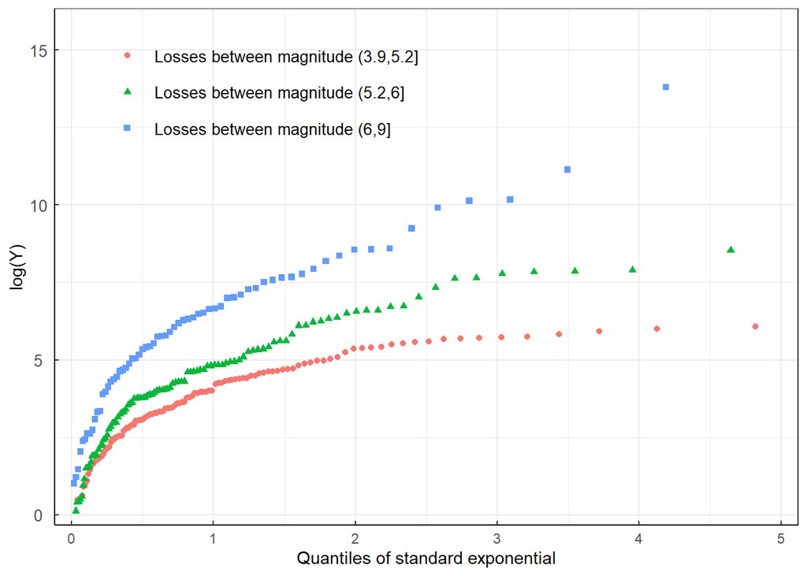

```r
library(ggplot2)
legend.name <- c(paste('Losses between magnitude', levels(dtnew$magnitude.f)[1]),
                 paste('Losses between magnitude', levels(dtnew$magnitude.f)[2]),
                 paste('Losses between magnitude', levels(dtnew$magnitude.f)[3]))
dtplot <- data.frame(x = c(m1$pqq.the, m2$pqq.the, m3$pqq.the),
                     logy = c(m1$pqq.emp, m2$pqq.emp, m3$pqq.emp),
                     group = factor(c(rep(1, each = length(m1$pqq.the)),
                               rep(2, each = length(m2$pqq.the)),
                               rep(3, each = length(m3$pqq.the)))))

p7  <- ggplot(data = dtplot,
              mapping = aes(x = x, y = logy, colour = group)) +
  theme_bw() + ylab('log(Y)') + xlab('Quantiles of standard exponential') +
  geom_point(aes(shape = group)) +
  scale_x_continuous(limits = c(0, 5),
                     breaks = seq(0, 5, by = 1),
                     expand = c(+0.02, +0.02)) +
  scale_y_continuous(limits = c(0, 16),
                     breaks = seq(0, 16, by = 5),
                     expand = c(+0.02, +0.02)) +
  scale_colour_discrete(labels = legend.name) +
  scale_shape_discrete(labels = legend.name) +
  theme(axis.line = element_line(colour = "black"),
        axis.text.x = element_text(margin = margin(t = 0.25, unit = "cm")),
        axis.text.y = element_text(margin = margin(r = 0.25, unit = "cm"),
                                   size = 10,
                                   vjust = 0.5,
                                   hjust = 0.5),
        axis.ticks.length = unit(-0.1, "cm"),
        plot.title = element_text(hjust = 0.5),
        legend.direction = 'vertical',
        legend.key.size = unit(0.8, "cm"),
        legend.key = element_blank(),
        legend.position = c(0.5, 1),
        legend.background=element_blank(),
        legend.justification = c("right", "top"),
        legend.box.just = "right",
        legend.margin = margin(t = 2, r = 5, b = 5, l = 5),
        #legend.background = element_rect(linetype = "solid", colour ="black"),
        legend.text = element_text(size = 10)) +
  labs(col = "", shape = '')
p7
```

```r
# ggsave("C:/坚果云同步/对外经济贸易大学 - 科研/0. Generalizing the log-Moyal distribution and regression models for heavy tailed loss data/合作文件 - 杨亮 - 文稿+代码/0. revised version/manuscript  - Astin/fig7.eps",
#       p7, device = cairo_ps)
```

### Figure 1: Chinese earthquakes since 1990. Top: boxplots of $\log$ of economic losses for intensity classes 6 to 9 and magnitude classes (3.9,5.2], (5.2,6], (6,9]; bottom: scatterplot of $\log$ of economic losses as a function of magnitude with intensity indicated by the color.

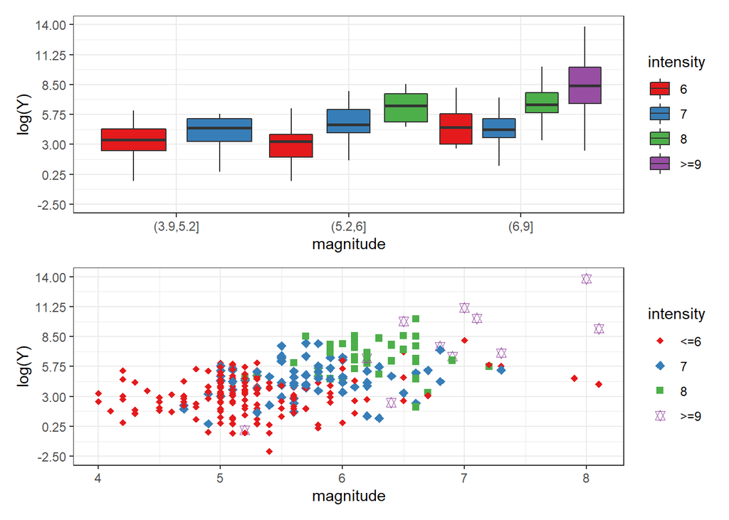

```r
cbp1 <- brewer.pal(4, name = "Set1")
dtnew[, magnitude.f := cut(magnitude, breaks = c(3.9, 5.2, 6, 9))]
dtnew[, class := paste(magnitude.f, intensity)]
dtplot0 <- dtnew[intensity %in% c(6, 7, 8, 9, 11)&!(class %in% c('(3.9,5.2] 8', '(3.9,5.2] 9'))]
dtplot0[, intensity.f := ifelse(intensity >= 9, '>=9', intensity)]
dtplot0[, intensity.f := factor(intensity.f, levels = c('6','7','8','>=9'))]
dtplot0[, class0 := paste(magnitude.f,intensity.f)]
p0_png  <- ggplot(data = dtplot0,
              mapping = aes(x = magnitude.f, y = log(ynew), fill = intensity.f)) +
  theme_bw() + ylab('log(Y)') + xlab('magnitude') +
  geom_boxplot(aes(fill = intensity.f,), position = position_dodge(1), outlier.colour = NA) +
  scale_y_continuous(limits = c(-2.5, 14),
                     breaks = seq(-2.5, 14, by = 2.75)) +
  scale_fill_manual(name = 'intensity', values = cbp1)


dtplotnew <- dtnew
dtplotnew[, intensity.f := ifelse(intensity == 11|intensity == 9, '>=9', intensity)]
dtplotnew[, intensity.f := ifelse(intensity <=6, '<=6', intensity.f)]
dtplotnew[, intensity.f := factor(intensity.f, levels = c('<=6','7','8','>=9'))]

p0new_png  <- ggplot(data = dtnew,
              mapping = aes(x = magnitude, y = log(ynew))) +
  theme_bw() + ylab('log(Y)') + xlab('magnitude') +
  geom_point(aes(shape = intensity.f, fill = intensity.f, col = intensity.f), size = 2) +
  xlab("magnitude") +
  ylab("log(Y)") +
  scale_shape_manual(name = 'intensity', values = c(18,23,15,11)) +
  scale_y_continuous(limits = c(-2.5, 14),
                     breaks = seq(-2.5, 14, by = 2.75)) +
  scale_color_manual(name = 'intensity', values = cbp1) +
  scale_fill_manual(name = 'intensity', values = cbp1)



# ggsave("C:/坚果云同步/对外经济贸易大学 - 科研/0. Generalizing the log-Moyal distribution and regression models for heavy tailed loss data/合作文件 - 杨亮 - 文稿+代码/0. revised version/manuscript  - Astin/figures/fig_introduction.eps",
#       p0, device = cairo_ps)
p0 <- p0_png + p0new_png + plot_layout(ncol = 1)
p0
```

## Competitng regressions on the earthquake data set.

```r
# read data set from local disk
dtnew <- fread('eqdata.csv', header = T)
y <- dtnew$ynew
X <- model.matrix(~ magnitude + intensity, data = dtnew) # design matrix
```

### 1. Log normal distribution

```r
# 1. log normal distribution -------------------------------------------------
LLlognormal <-  function(pars, y, X){
  lengthpar <- dim(X)[2]
  mu <- (X%*%pars[1:lengthpar])
  sigma <- exp(pars[lengthpar+1])
  logL <- dLOGNO(y, mu, sigma, log = T)
  ll <- -sum(logL)
  return(ll)
}
mllognormal <- optim(fn = LLlognormal,
                     X = X, y = y,
                     control = list(maxit = 100000),
                     par = rep(times = (dim(X)[2]+1), x = 1),
                     hessian = T)
pars <- mllognormal$par
lengthpar <- dim(X)[2]
mu <- (X%*%pars[1:lengthpar])
sigma <- exp(pars[lengthpar+1])
ufit <- pLOGNO(y, mu, sigma)
reslognormal <- qnorm(ufit) # random quantile residuals
modout(mllognormal) # output of estimates results
```

```
## $summary
##    m.par    se      Z p
## 1 -6.945 0.833 -8.333 0
## 2  0.626 0.171  3.664 0
## 3  1.163 0.133  8.718 0
## 4  0.530 0.041 12.777 0
##
## $ll
## [1] -1798.385
##
## $AIC
## [1] 3604.769
##
## $BIC
## [1] 3619.463
```

### 2. Weibull distribution

```r
# 1.2 Weibull distribution -------------------------------------------------------------
LLweibull <- function(pars, y, X){
  lengthpar <- dim(X)[2]
  a <- exp(pars[lengthpar+1])  # shape
  b <- exp(X %*% pars[1:lengthpar]) # scale
  logL <- dweibull(y, shape = a, scale = b, log = T)
  return(-sum(logL))
}
mlweibull <- optim(f = LLweibull,
                 y = y, X = X,
                 control = list(maxit = 100000),
                 par = rnorm(n = (dim(X)[2]+1), 0, 0.1),
                 hessian = T)
pars <- mlweibull$par
lengthpar <- dim(X)[2]
a <- exp(pars[lengthpar+1])  # shape
b <- exp(X %*% pars[1:lengthpar]) # scale
ufit <- pweibull(y, shape = a, scale = (b))
resweibull <- qnorm(ufit)
modout(mlweibull)
```

```
## $summary
##    m.par    se      Z     p
## 1 -0.159 1.312 -0.121 0.904
## 2  0.279 0.216  1.296 0.195
## 3  0.606 0.157  3.858 0.000
## 4 -0.575 0.078 -7.376 0.000
##
## $ll
## [1] -1849.708
##
## $AIC
## [1] 3707.416
##
## $BIC
## [1] 3722.109
```

### 3. GB2 distribution

```r
# 1.3 GBII distribution (- covariates only in mu) -------------------------------------------------------------
LLGB2 <- function(pars, y, X){
  lengthpar <- dim(X)[2]
  sigma <- exp(pars[lengthpar+3])  # shape
  mu <- exp(X %*% pars[1:lengthpar]) # scale
  nu <- exp(pars[lengthpar+1])
  tau <- exp(pars[lengthpar+2])
  logL <- dGB2(y, mu = mu, sigma = sigma, nu = nu, tau = tau, log = T)
  return(-sum(logL))
}
mlGB2 <- optim(fn = LLGB2, y = y, X = X,
             par = c(-1, 1, 0.1, 0.1, 0.05, 0.1),
             control = list(maxit = 100000),
             hessian = T)


pars <- mlGB2$par
lengthpar <- dim(X)[2]
sigma <- exp(pars[lengthpar+3])  # shape
mu <- exp(X %*% pars[1:lengthpar]) # scale
nu <- exp(pars[lengthpar+1])
tau <- exp(pars[lengthpar+2])
ufit <- pGB2(y, mu = mu, sigma = sigma, nu = nu, tau = tau)
resGB2 <- qnorm(ufit)

modout(mlGB2)
```

```
## $summary
##    m.par    se      Z     p
## 1 -4.565 3.604 -1.267 0.205
## 2  0.615 0.173  3.547 0.000
## 3  1.257 0.131  9.590 0.000
## 4  0.648 0.831  0.780 0.435
## 5  2.009 1.893  1.061 0.289
## 6 -0.625 0.592 -1.056 0.291
##
## $ll
## [1] -1791.247
##
## $AIC
## [1] 3594.494
##
## $BIC
## [1] 3616.534
```

### 4. GLMGA I

```r
# 1.4 GLMGA I (covariates only in sigma) -------------------------------------------------------------
LLlogmoyalGA <- function(y, pars, X) {
  lengthpar <- dim(X)[2]
  sigma <- exp(X %*% pars[1:lengthpar])
  b <- exp(pars[lengthpar+1])
  kappa <- exp(pars[lengthpar+2])
  ll <- -0.5*log(2*pi) - log(sigma) + kappa*log(b) + lgamma(kappa + 0.5) - lgamma(kappa) - (1/(2*sigma)+1)*log(y) - (kappa + 0.5)*log(0.5*(1/y)^(1/sigma) + b)

  loglike <- -sum(ll)
  return(loglike)
}

mlogmoyalGA <- optim(fn = LLlogmoyalGA, X = X,
                     par = c(-1, 0.3,0.1, 1, -1.3),
                     control = list(maxit = 100000),
                     y = y, hessian = T)

pars <- mlogmoyalGA$par
lengthpar <- dim(X)[2]
sigma <- exp(X %*% pars[1:lengthpar])
b <- exp(pars[lengthpar+1])
a <- exp(pars[lengthpar+2])
ufit <- c()
for(i in 1:length(y)){
  ufit[i] <- pLMGA(y[i], sigma = sigma[i], a = a, b = b)
}
resLMGA <- qnorm(ufit)
modout(mlogmoyalGA)
```

```
## $summary
##     m.par    se       Z     p
## 1  -2.767 0.177 -15.655 0.000
## 2   0.091 0.035   2.601 0.009
## 3   0.227 0.028   8.194 0.000
## 4 -10.415 1.300  -8.014 0.000
## 5  -1.080 0.167  -6.452 0.000
##
## $ll
## [1] -1798.537
##
## $AIC
## [1] 3607.073
##
## $BIC
## [1] 3625.44
```

### 5. GLMGA II

```r
# 1.5 GLMGA II (covariates only in b) -------------------------------------------------------------
LLlogmoyalGA2 <- function(y, pars, X) {
  lengthpar <- dim(X)[2]
  b <- exp(X %*%pars[1:lengthpar])
  sigma <- exp(pars[lengthpar+1])
  a <- exp(pars[lengthpar+2])
  ll <- -0.5*log(2*pi) - log(sigma) + a*log(b) + lgamma(a + 0.5) - lgamma(a) - (1/(2*sigma)+1)*log(y) - (a + 0.5)*log(0.5*(1/y)^(1/sigma) + b)

  loglike <- -sum(ll)
  return(loglike)
}
pars <- c(1,1)
mlogmoyalGA2 <- optim(par = rep(times = (dim(X)[2]+2), x = 0.1),
                   fn = LLlogmoyalGA2, X = X,
                   control = list(maxit = 100000),
                   y = y, hessian = T)

pars <- mlogmoyalGA2$par
lengthpar <- dim(X)[2]
b <- exp(X %*%pars[1:lengthpar])
sigma <- exp(pars[lengthpar+1])
a <- exp(pars[lengthpar+2])
ufit <- c()
for(i in 1:length(y)){
  ufit[i] <- pLMGA(y[i], sigma = sigma, a = a, b = b[i])
}
resLMGA2 <- qnorm(ufit)

modout(mlogmoyalGA2)
```

```
## $summary
##    m.par    se      Z     p
## 1  1.149 1.927  0.596 0.551
## 2  0.098 0.343  0.285 0.775
## 3 -1.733 0.318 -5.450 0.000
## 4 -0.648 0.100 -6.477 0.000
## 5 -1.040 0.183 -5.671 0.000
##
## $ll
## [1] -1818.145
##
## $AIC
## [1] 3646.29
##
## $BIC
## [1] 3664.657
```

### 6. GLMGA III

```r
# 1.6 GLMGA III (magnitude is introduced in sigma, intensity is introduced in b) -------------------------------------------------------------
Xsigma <- model.matrix(~ magnitude, data = dtnew);
Xb <- model.matrix(~ intensity, data = dtnew)
LLlogmoyalGA3 <- function(y, pars, Xsigma, Xb) {
  sigma <- exp(Xsigma %*% pars[1:dim(Xsigma)[2]])
  b <- exp(Xb %*%pars[(dim(Xsigma)[2]+1):(dim(Xsigma)[2] + dim(Xb)[2])])
  a <- exp(pars[dim(Xsigma)[2] + dim(Xb)[2]+1])
  ll <- -0.5*log(2*pi) - log(sigma) + a*log(b) + lgamma(a + 0.5) - lgamma(a) - (1/(2*sigma)+1)*log(y) - (a + 0.5)*log(0.5*(1/y)^(1/sigma) + b)

  loglike <- -sum(ll)
  return(loglike)
}
mlogmoyalGA3 <- optim(fn = LLlogmoyalGA3, Xsigma = Xsigma,
                     Xb = Xb,
                     y = y, hessian = T,
                     control = list(maxit = 50000),
                     par = c(-1,-0.1,0.5,-2,-1))

pars <- mlogmoyalGA3$par
sigma <- exp(Xsigma %*% pars[1:dim(Xsigma)[2]])
b <- exp(Xb %*%pars[(dim(Xsigma)[2]+1):(dim(Xsigma)[2] + dim(Xb)[2])])
a <- exp(pars[dim(Xsigma)[2] + dim(Xb)[2]+1])
ufit <- c()
for(i in 1:length(y)){
  ufit[i] <- pLMGA(y[i], sigma = sigma[i], a = a, b = b[i])
}
resLMGA3 <- qnorm(ufit)
modout(mlogmoyalGA3)
```

```
## $summary
##    m.par    se      Z     p
## 1 -1.392 0.190 -7.340 0.000
## 2  0.113 0.030  3.755 0.000
## 3  6.485 1.976  3.282 0.001
## 4 -2.592 0.419 -6.188 0.000
## 5 -1.065 0.176 -6.062 0.000
##
## $ll
## [1] -1792.384
##
## $AIC
## [1] 3594.769
##
## $BIC
## [1] 3613.135
```

### 7. Log moyal regression

```r
# 1.7 log moyal distribution -------------------------------------------------------------
LLlogmoyal <- function(y, pars, X) {
  lengthpar <- dim(X)[2]
  sigma <- exp(X %*% pars[1:lengthpar])
  tau <- exp(pars[lengthpar+1])
  ll <- 0.5*log(tau) - 0.5*log(2*pi) - log(sigma) - (1/(2*sigma) + 1)*log(y) - tau/2*(1/y)^(1/sigma)

  loglike <- -sum(ll)
  return(loglike)
}
mlogmoyal <- optim(fn = LLlogmoyal, X = X,
                    par = c(0.1, 0.3, 0.1, 0.1),
                    y = y, hessian = T)
pars <- mlogmoyal$par
lengthpar <- dim(X)[2]
sigma <- exp(X %*% pars[1:lengthpar])
tau <- exp(pars[lengthpar+1])
ufit <- c()
for(i in 1:length(y)){
  ufit[i] <- pGlogM(y[i], sigma = sigma[i], tau = tau)
}
resGlogM <- qnorm(ufit)
modout(mlogmoyal)
```

```
## $summary
##    m.par    se      Z     p
## 1 -1.960 0.319 -6.147 0.000
## 2  0.151 0.067  2.244 0.025
## 3  0.220 0.052  4.215 0.000
## 4  1.947 0.091 21.283 0.000
##
## $ll
## [1] -1876.039
##
## $AIC
## [1] 3760.078
##
## $BIC
## [1] 3774.772
```

### 8. Exponentiated Frechet regression

```r
# 1.8 exponentiated Frechet regression -------------------------------------------------------------
LLeFrechet <- function(y, pars, X) {
  lengthpar <- dim(X)[2]
  lambda <- exp(X %*% pars[1:lengthpar])
  tau <- exp(pars[lengthpar+1])
  alpha <- exp(pars[lengthpar+2])

  ll <- log(alpha) + log(tau) + log(lambda) + (alpha - 1)*log(1 - exp(-tau/y^lambda)) - (1+lambda)*log(y) - tau/y^lambda
  loglike <- -sum(ll)
  return(loglike)
}
meFrechet <- optim(fn = LLeFrechet, X = X,
                   par = c(-0.8,-0.2,0.1,2.5,0),
                   control = list(maxit = 50000),
                   y = y, hessian = T)
pars <- meFrechet$par
lengthpar <- dim(X)[2]
lambda <- exp(X %*% pars[1:lengthpar])
tau <- exp(pars[lengthpar+1])
alpha <- exp(pars[lengthpar+2])
ufit <- c()
peFrechet <- function(y, lambda, tau, alpha){
  sigma <- tau^(1/lambda)
  1 - (1 - exp(-(sigma/y)^lambda))^alpha
  }
for(i in 1:length(y)){
  ufit[i] <- peFrechet(y[i], lambda = lambda[i], tau = tau, alpha = alpha)
}
reseFrechet <- qnorm(ufit)
modout(meFrechet)
```

```
## $summary
##    m.par    se      Z     p
## 1 -0.440 0.390 -1.128 0.259
## 2 -0.123 0.031 -3.908 0.000
## 3 -0.181 0.025 -7.147 0.000
## 4  2.359 0.197 11.955 0.000
## 5  6.639 2.296  2.891 0.004
##
## $ll
## [1] -1795.279
##
## $AIC
## [1] 3600.559
##
## $BIC
## [1] 3618.925
```

### 9. Burr regression

```r
# 1.9 burr regression -------------------------------------------------------------
LLburr <- function(y, pars, X) {
  lengthpar <- dim(X)[2]
  tau <- exp(X %*% pars[1:lengthpar])
  lambda <- exp(pars[lengthpar+1])
  beta <- exp(pars[lengthpar+2])

  ll <- log(lambda) + lambda*log(beta) + log(tau) + (tau-1)*log(y) - (lambda+1)*log(beta+y^tau)
  loglike <- -sum(ll)
  return(loglike)
}
mburr <- optim(fn = LLburr, X = X,
               par = c(2, -1, -1, -1, 5),
               y = y, hessian = T)
pars <- mburr$par
lengthpar <- dim(X)[2]
tau <- exp(X %*% pars[1:lengthpar])
lambda <- exp(pars[lengthpar+1])
beta <- exp(pars[lengthpar+2])
ufit <- c()
pburrnew <- function(y, lambda, beta, tau){1 - (beta/(beta + y^tau))^lambda}
for(i in 1:length(y)){
  ufit[i] <- pburrnew(y[i], lambda = lambda, tau = tau[i], beta = beta)
}
resburr <- qnorm(ufit)
modout(mburr)
```

```
## $summary
##    m.par    se      Z     p
## 1  1.748 0.199  8.762 0.000
## 2 -0.112 0.035 -3.251 0.001
## 3 -0.200 0.029 -6.979 0.000
## 4  0.933 0.398  2.345 0.019
## 5  4.627 0.300 15.427 0.000
##
## $ll
## [1] -1796.337
##
## $AIC
## [1] 3602.674
##
## $BIC
## [1] 3621.041
```

### 10. Gamma-generalized inverse gaussian regression

```r
# 2.0 gamma-generalized inverse gaussian regression -------------------------------------------------------------
LLGAGIG <- function(y, pars, X) {
  lengthpar <- dim(X)[2]
  t <- exp(X %*% pars[1:lengthpar])
  a <- exp(pars[lengthpar+1])
  lambda <- exp(pars[lengthpar+2])
  mu <- exp(pars[lengthpar+3])
  phi <- exp(pars[lengthpar+4])

  munew <- mu*sqrt(phi/(phi+2*mu^2*t*y))
  K1 <- besselK(x = phi/munew, nu = (a+lambda))
  K2 <- besselK(x = phi/mu, nu = (lambda))

  ll <- a*(log(y) + log(t) + log(mu)) - log(y) - lgamma(a) + (a+lambda)/2*(log(phi) - log(phi+2*mu^2*t*y)) + log(K1) - log(K2)
  loglike <- -sum(ll)
  return(loglike)
}

mGAGIG <- optim(fn = LLGAGIG, X = X,
               par = c(2, -1,-1,1,1,-1,-1),
               control = list(maxit = 50000),
               y = y, hessian = T)
pars <- mGAGIG$par
lengthpar <- dim(X)[2]
t <- exp(X %*% pars[1:lengthpar])
a <- exp(pars[lengthpar+1])
lambda <- exp(pars[lengthpar+2])
mu <- exp(pars[lengthpar+3])
phi <- exp(pars[lengthpar+4])
pGAGIG <- function(y, t, a, lambda, mu){
  pGAGIG <- function(y, t , a, lambda, mu){
    munew <- mu*sqrt(phi/(phi+2*mu^2*t*y))
    K1 <- besselK(x = phi/munew, nu = (a+lambda))
    K2 <- besselK(x = phi/mu, nu = (lambda))
    ll <- a*(log(y) + log(t) + log(mu)) - log(y) - lgamma(a) + (a+lambda)/2*(log(phi) - log(phi+2*mu^2*t*y)) + log(K1) - log(K2)
    exp(ll)
  }
  z <- c()
  for (i in 1:length(y)){
    pnew <- function(y){
      pGAGIG(y, t = t[i], a = a, lambda = lambda, mu = mu)
    }
    z[i] = integrate(pnew, lower = 0, upper = y[i])$value
  }
  z
}
ufit <- c()
ufit <- pGAGIG(y = y, t = t, a = a, lambda = lambda, mu = mu)
resGAGIG <- qnorm(ufit)
modout(mGAGIG)
```

```
## $summary
##    m.par       se      Z     p
## 1  3.034 2422.335  0.001 0.999
## 2 -0.551    0.164 -3.362 0.001
## 3 -1.291    0.129 -9.994 0.000
## 4 -0.180    0.113 -1.589 0.112
## 5  0.520    0.206  2.524 0.012
## 6 -0.014 2422.321  0.000 1.000
## 7 -2.595 2422.297 -0.001 0.999
##
## $ll
## [1] -1792.071
##
## $AIC
## [1] 3598.141
##
## $BIC
## [1] 3623.854
```

### 11. Gamma regression distribution

```r
# 2.1 gamma regression distribution -------------------------------------------------------------
LLgamma <- function(y, pars, X) {
  lengthpar <- dim(X)[2]
  mu <- exp(X %*% pars[1:lengthpar])
  sigma <- exp(pars[lengthpar+1])

  ll <- dGA(y, mu = mu, sigma = sigma, log = T)
  loglike <- -sum(ll)
  return(loglike)
}
mgamma <- optim(fn = LLgamma, X = X,
                par = rep(times = (dim(X)[2]+1), x = 1),
                control = list(maxit = 50000),
                y = y, hessian = T)
pars <- mgamma$par
lengthpar <- dim(X)[2]
mu <- exp(X %*% pars[1:lengthpar])
sigma <- exp(pars[lengthpar+1])
ufit <- c()
ufit <- pGA(y, mu = mu, sigma = sigma)
resgamma <- qnorm(ufit)
modout(mgamma)
```

```
## $summary
##    m.par    se       Z p
## 1 -7.061 0.581 -12.156 0
## 2  0.852 0.138   6.192 0
## 3  1.160 0.102  11.375 0
## 4  0.291 0.035   8.402 0
##
## $ll
## [1] -1805.421
##
## $AIC
## [1] 3618.841
##
## $BIC
## [1] 3633.534
```

### 12. Inverse guaissn regression distribution

```r
# 2.2 inverse guaissn regression distribution -------------------------------------------------------------
LLigua <- function(y, pars, X) {
  lengthpar <- dim(X)[2]
  mu <- exp(X %*% pars[1:lengthpar])
  sigma <- exp(pars[lengthpar+1])

  ll <- dIG(y, mu = mu, sigma = sigma, log = T)
  loglike <- -sum(ll)
  return(loglike)
}
migua <- optim(fn = LLigua, X = X,
                par = c(-5,1,1,1),
                control = list(maxit = 50000),
                y = y, hessian = T)
pars <- migua$par
lengthpar <- dim(X)[2]
mu <- exp(X %*% pars[1:lengthpar])
sigma <- exp(pars[lengthpar+1])
ufit <- c()
ufit <- pIG(y, mu = mu, sigma = sigma)
resigua <- qnorm(ufit)
modout(migua)
```

```
## $summary
##    m.par    se       Z     p
## 1 -3.814 1.729  -2.206 0.027
## 2  0.974 0.537   1.813 0.070
## 3  0.545 0.438   1.245 0.213
## 4 -1.129 0.042 -27.093 0.000
##
## $ll
## [1] -1931.52
##
## $AIC
## [1] 3871.04
##
## $BIC
## [1] 3885.734
```

### 13. Exp - inverse guaissn regression distribution

```r
# 2.3 exp - inverse guaissn regression distribution -------------------------------------------------------------
LLexpigua <- function(y, pars, X) {
  lengthpar <- dim(X)[2]
  t <- exp(X %*% pars[1:lengthpar])
  delta <- exp(pars[lengthpar+1])
  phi <- (delta^2+2*y/t)^(0.5)

  ll <- log(delta)-log(t)-delta*phi-delta^2-3*log(phi)+log(delta*phi+1)
  loglike <- -sum(ll)
  return(loglike)
}
mexpigua <- optim(fn = LLexpigua, X = X,
               par = c(-1,1,1,1),
               control = list(maxit = 50000),
               y = y, hessian = T)
pexpigua <- function(y, delta, t){
  phi <- (delta^2+2*y/t)^(0.5)
  1 - delta*exp(-delta*(phi-delta))/phi
}
pars <- mexpigua$par
lengthpar <- dim(X)[2]
t <- exp(X %*% pars[1:lengthpar])
delta <- exp(pars[lengthpar+1])
phi <- (delta^2+2*y/t)^(0.5)
ufit <- c()
ufit <- pexpigua(y, delta = delta, t = t)
resexpigua <- qnorm(ufit)
modout(mexpigua)
```

```
## $summary
##    m.par    se      Z     p
## 1  1.144 3.740  0.306 0.760
## 2  0.549 0.204  2.696 0.007
## 3  1.209 0.169  7.137 0.000
## 4 -4.115 1.791 -2.297 0.022
##
## $ll
## [1] -1825.755
##
## $AIC
## [1] 3659.51
##
## $BIC
## [1] 3674.204
```

### 14. Lomax regression

```r
# 2.4 Pareto distribution ( Lomax regression)
pars <- rep(times = (dim(X)[2] + 1), x = 1)
LLpareto <- function(pars, y, X){
  lengthpar <- dim(X)[2]
  beta <- exp(pars[lengthpar+1])
  sigma <- exp(X%*%pars[1:lengthpar])
  logL <- log(beta) + beta*log(sigma) - (beta+1)*log(y+sigma)
  ll <- -sum(logL)
  return(ll)
}
mlpareto <- optim(fn = LLpareto,
                  y = y, X = X, control = list(maxit = 100000),
                  par = rep(times = (dim(X)[2]+1), x = 0.1), hessian = T)
mlpareto
```

```
## $par
## [1] -6.6211432  0.5409557  1.2755965  0.3633125
##
## $value
## [1] 1793.335
##
## $counts
## function gradient
##      491       NA
##
## $convergence
## [1] 0
##
## $message
## NULL
##
## $hessian
##           [,1]      [,2]      [,3]       [,4]
## [1,]  119.0655  657.3455   784.069  -171.6365
## [2,]  657.3455 3690.8524  4374.012  -952.0156
## [3,]  784.0690 4374.0121  5258.587 -1137.1779
## [4,] -171.6365 -952.0156 -1137.178   290.9722
```

```r
pars <- mlpareto$par
lengthpar <- dim(X)[2]
beta <- exp(pars[lengthpar+1])
sigma <- exp(X%*%pars[1:lengthpar])
for (i in 1:length(y)){
  ufit[i] <- ppareto2(y[i], shape = beta, scale = sigma[i])
}
respareto <- qnorm(ufit)
modout(mlpareto)
```

```
## $summary
##    m.par    se      Z     p
## 1 -6.621 0.790 -8.380 0.000
## 2  0.541 0.158  3.430 0.001
## 3  1.276 0.127 10.031 0.000
## 4  0.363 0.152  2.383 0.017
##
## $ll
## [1] -1793.335
##
## $AIC
## [1] 3594.67
##
## $BIC
## [1] 3609.364
```

### 15. DPLN regression

```r
LLDPLN <- function(pars, X, y){
  lengthpar <- dim(X)[2]
  lambda1 <- (pars[1])
  lambda2 <- (pars[2])
  tau <- (pars[3])
  v <- X %*% pars[4:(lengthpar + 3)]
  if (lambda1 > 0 &  lambda2 > 0 & tau >0 & any(v > 1)) {
    logL <- dDPLN(y, lambda1 = lambda1, lambda2 = lambda2, v = v, tau = tau, log.p = TRUE)
    ll <- -sum(logL)
  } else {
    ll <- 1e100
  }
  return(ll)
}
mDPLN <- optim(fn = LLDPLN,
               y = y,
               par = c(5, 3, 1, -1, 1, 3),
               X = X,
               hessian = T,
               control = list(maxit = 10000000))

pars <- mDPLN$par
lengthpar <- dim(X)[2]
lambda1 <- (pars[1])
lambda2 <- (pars[2])
tau <- (pars[3])
v <- X %*% pars[4:(lengthpar + 3)]
ufit <- c()
for(i in 1:length(y)){
  ufit[i] <- pDPLN(y[i], lambda1 = lambda1, lambda2 = lambda2, tau = tau, v = v[i])
}

resDPLN <- qnorm(ufit)
modout(mDPLN)
```

```
## $summary
##    m.par    se        Z     p
## 1  5.828 2.932    1.988 0.047
## 2  3.404 0.003 1186.105 0.000
## 3  1.859 0.003  665.203 0.000
## 4  0.191 0.003   56.383 0.000
## 5 -0.262 0.003  -87.426 0.000
## 6  0.866 0.003  280.206 0.000
##
## $ll
## [1] -1833.228
##
## $AIC
## [1] 3678.456
##
## $BIC
## [1] 3700.496
```

### 16. Generalized Pareto regression

```r
umin <- 0
GPD2.MLE <- fevd(x = ynew,
                 scale.fun = ~ 1,
                 shape.fun = ~ magnitude + intensity,
                 threshold = 0, method = 'MLE', use.phi = F,
                 type = "GP", data = dtnew)
GPD2.par <- GPD2.MLE$results$par
pars <- GPD2.MLE$results$par
scale <- pars[1]
shape <- X%*%pars[2:4]
ufit <- c()
for(i in 1:length(y)){
  ufit[i] <- POT::pgpd(y[i], loc = umin, scale = scale, shape = shape[i])
}
resGPD <- qnorm(ufit) ## p value
mlGPD <- GPD2.MLE$results
modout(mlGPD)
```

```
## $summary
##        m.par    se      Z p
## scale 53.596 7.328  7.314 0
## xi0   -5.831 0.731 -7.978 0
## xi1    0.553 0.150  3.676 0
## xi2    0.584 0.098  5.947 0
##
## $ll
## [1] -1833.634
##
## $AIC
## [1] 3675.268
##
## $BIC
## [1] 3689.961
```

## Estimates of all models, Goodness-fit and VaR estimation

### Table 10: Estimates of the GLMGA regression on the earthquake data set

```r
result.GLMGA <- data.table(cbind(modout(mlogmoyalGA)$summary[1:2],modout(mlogmoyalGA2)$summary[1:2],modout(mlogmoyalGA3)$summary[1:2]))

kable(round(result.GLMGA, 2))
```

| m.par | se | m.par | se | m.par | se |
| --- | --- | --- | --- | --- | --- |
| -2.77 | 0.18 | 1.15 | 1.93 | -1.39 | 0.19 |
| 0.09 | 0.04 | 0.10 | 0.34 | 0.11 | 0.03 |
| 0.23 | 0.03 | -1.73 | 0.32 | 6.49 | 1.98 |
| -10.41 | 1.30 | -0.65 | 0.10 | -2.59 | 0.42 |
| -1.08 | 0.17 | -1.04 | 0.18 | -1.06 | 0.18 |

### Table 11: Log-likelihood, AIC, and BIC for the competing models, along with rankings induced by these criteria.

```r
# results for all models -------------------------------------------------------------
npars.com <- rbind(nrow(modout(mlpareto)$summary),
                   nrow(modout(mllognormal)$summary),
                   nrow(modout(mlweibull)$summary),
                   nrow(modout(mlGB2)$summary),
                   nrow(modout(mlogmoyalGA)$summary),
                   nrow(modout(mlogmoyalGA2)$summary),
                   nrow(modout(mlogmoyalGA3)$summary),
                   nrow(modout(mlogmoyal)$summary),
                   nrow(modout(meFrechet)$summary),
                   nrow(modout(mburr)$summary),
                   nrow(modout(mGAGIG)$summary),
                   nrow(modout(mgamma)$summary),
                   nrow(modout(migua)$summary),
                   nrow(modout(mexpigua)$summary),
                   nrow(modout(mDPLN)$summary),
                   nrow(modout(mlGPD)$summary))

loglike.com <- rbind(modout(mlpareto)$ll,
                     modout(mllognormal)$ll,
                     modout(mlweibull)$ll,
                     modout(mlGB2)$ll,
                     modout(mlogmoyalGA)$ll,
                     modout(mlogmoyalGA2)$ll,
                     modout(mlogmoyalGA3)$ll,
                     modout(mlogmoyal)$ll,
                     modout(meFrechet)$ll,
                     modout(mburr)$ll,
                     modout(mGAGIG)$ll,
                     modout(mgamma)$ll,
                     modout(migua)$ll,
                     modout(mexpigua)$ll,
                     modout(mDPLN)$ll,
                     modout(mlGPD)$ll
                     )

AIC.com <- rbind(modout(mlpareto)$AIC, modout(mllognormal)$AIC,
                 modout(mlweibull)$AIC,
                 modout(mlGB2)$AIC,
                 modout(mlogmoyalGA)$AIC,
                 modout(mlogmoyalGA2)$AIC,
                 modout(mlogmoyalGA3)$AIC,
                 modout(mlogmoyal)$AIC,
                 modout(meFrechet)$AIC,
                 modout(mburr)$AIC,
                 modout(mGAGIG)$AIC,
                 modout(mgamma)$AIC,
                 modout(migua)$AIC,
                 modout(mexpigua)$AIC,
                 modout(mDPLN)$AIC,
                 modout(mlGPD)$AIC)

BIC.com <- rbind(modout(mlpareto)$BIC, modout(mllognormal)$BIC,
                 modout(mlweibull)$BIC,
                 modout(mlGB2)$BIC,
                 modout(mlogmoyalGA)$BIC,
                 modout(mlogmoyalGA2)$BIC,
                 modout(mlogmoyalGA3)$BIC,
                 modout(mlogmoyal)$BIC,
                 modout(meFrechet)$BIC,
                 modout(mburr)$BIC,
                 modout(mGAGIG)$BIC,
                 modout(mgamma)$BIC,
                 modout(migua)$BIC,
                 modout(mexpigua)$BIC,
                 modout(mDPLN)$BIC,
                 modout(mlGPD)$BIC)

convergence.com <- rbind(modout(mlpareto)$convergence,
                         (mllognormal)$convergence,
                         (mlweibull)$convergence,
                         (mlGB2)$convergence,
                         (mlogmoyalGA)$convergence,
                         (mlogmoyalGA2)$convergence,
                         (mlogmoyalGA3)$convergence,
                         (mlogmoyal)$convergence,
                         (meFrechet)$convergence,
                         (mburr)$convergence,
                         (mGAGIG)$convergence,
                         (mgamma)$convergence,
                         (migua)$convergence,
                         (mexpigua)$convergence,
                         (mDPLN)$convergence,
                         (mlGPD)$convergence)


row.names(AIC.com) <- c('Lomax','lognormal', 'weibull', 'GB2',
                        'logmoyalGA','logmoyalGA2','logmoyalGA3',
                        'GlogM', 'eFrechet', 'burr', 'GAGIG',
                        'gamma', 'ig', 'expigua','DPLN', 'GP')
row.names(BIC.com) <- c('Lomax', 'lognormal', 'weibull', 'GB2',
                        'logmoyalGA','logmoyalGA2','logmoyalGA3',
                        'GlogM', 'eFrechet', 'burr', 'GAGIG',
                        'gamma', 'ig','expigua','DPLN', 'GP')
colnames(AIC.com) <- 'AIC'
colnames(BIC.com) <- 'BIC'
colnames(loglike.com) <- 'loglike'
colnames(npars.com) <- 'npars'
outtable <- round(cbind(npars.com, loglike.com, AIC.com, BIC.com), 1)
outtable <- round(cbind(npars.com, loglike.com, AIC.com, BIC.com), 1)
table12.1 <- outtable[order(outtable[,3], decreasing = F),]  # AIC sorting
table12.2 <- outtable[order(outtable[,4], decreasing = F),]  # BIC sorting
```

- Table 12: AIC sorting

```r
kable(table12.1)
```

|  | npars | loglike | AIC | BIC |
| --- | --- | --- | --- | --- |
| GB2 | 6 | -1791.2 | 3594.5 | 3616.5 |
| Lomax | 4 | -1793.3 | 3594.7 | 3609.4 |
| logmoyalGA3 | 5 | -1792.4 | 3594.8 | 3613.1 |
| GAGIG | 7 | -1792.1 | 3598.1 | 3623.9 |
| eFrechet | 5 | -1795.3 | 3600.6 | 3618.9 |
| burr | 5 | -1796.3 | 3602.7 | 3621.0 |
| lognormal | 4 | -1798.4 | 3604.8 | 3619.5 |
| logmoyalGA | 5 | -1798.5 | 3607.1 | 3625.4 |
| gamma | 4 | -1805.4 | 3618.8 | 3633.5 |
| logmoyalGA2 | 5 | -1818.1 | 3646.3 | 3664.7 |
| expigua | 4 | -1825.8 | 3659.5 | 3674.2 |
| GP | 4 | -1833.6 | 3675.3 | 3690.0 |
| DPLN | 6 | -1833.2 | 3678.5 | 3700.5 |
| weibull | 4 | -1849.7 | 3707.4 | 3722.1 |
| GlogM | 4 | -1876.0 | 3760.1 | 3774.8 |
| ig | 4 | -1931.5 | 3871.0 | 3885.7 |

- Table 12: BIC sorting

```r
kable(table12.2)
```

|  | npars | loglike | AIC | BIC |
| --- | --- | --- | --- | --- |
| Lomax | 4 | -1793.3 | 3594.7 | 3609.4 |
| logmoyalGA3 | 5 | -1792.4 | 3594.8 | 3613.1 |
| GB2 | 6 | -1791.2 | 3594.5 | 3616.5 |
| eFrechet | 5 | -1795.3 | 3600.6 | 3618.9 |
| lognormal | 4 | -1798.4 | 3604.8 | 3619.5 |
| burr | 5 | -1796.3 | 3602.7 | 3621.0 |
| GAGIG | 7 | -1792.1 | 3598.1 | 3623.9 |
| logmoyalGA | 5 | -1798.5 | 3607.1 | 3625.4 |
| gamma | 4 | -1805.4 | 3618.8 | 3633.5 |
| logmoyalGA2 | 5 | -1818.1 | 3646.3 | 3664.7 |
| expigua | 4 | -1825.8 | 3659.5 | 3674.2 |
| GP | 4 | -1833.6 | 3675.3 | 3690.0 |
| DPLN | 6 | -1833.2 | 3678.5 | 3700.5 |
| weibull | 4 | -1849.7 | 3707.4 | 3722.1 |
| GlogM | 4 | -1876.0 | 3760.1 | 3774.8 |
| ig | 4 | -1931.5 | 3871.0 | 3885.7 |

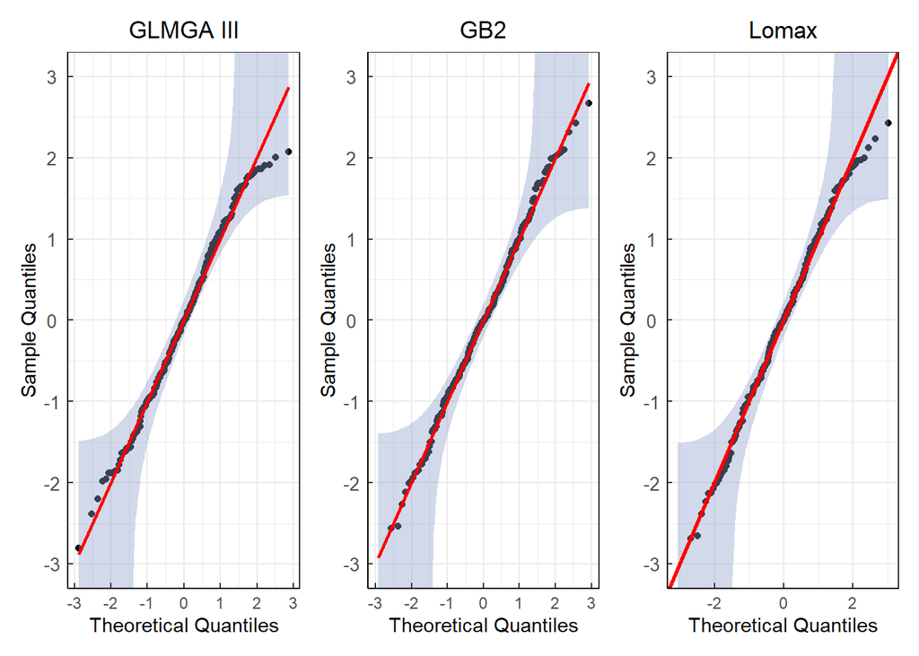

```r
# QQ - plot
newtheme <- theme_bw() + theme(axis.line = element_line(colour = "black"),
                               axis.text.x = element_text(margin = margin(t = 0.25, unit = "cm")),
                               axis.text.y = element_text(margin = margin(r = 0.25, unit = "cm"),
                                                          size = 10,
                                                          vjust = 0.5,
                                                          hjust = 0.5),
                               axis.ticks.length = unit(-0.1, "cm"),
                               plot.title = element_text(hjust = 0.5),
                               legend.direction = 'vertical',
                               legend.position = c(.95, .99),
                               legend.justification = c("right", "top"),
                               legend.box.just = "right",
                               legend.text = element_text(size = 10))
df <- data.frame(resLMGA3 = resLMGA3,
                 resGB2 = resGB2,
                 respareto = respareto)

p92 <-  ggplot(df, aes(sample = resLMGA3)) +
  stat_qq_point()  + stat_qq_band(bandType = "ks", fill = "#8DA0CB", alpha = 0.4, conf = 0.95) +
  stat_qq_line(col = 'red', identity = TRUE) + newtheme + labs(title = "GLMGA III", x = "Theoretical Quantiles", y = "Sample Quantiles") +
  scale_y_continuous(limits = c(-3, 3),
                     breaks = seq(-3, 3, by = 1))
p93 <-  ggplot(df, aes(sample = resGB2)) +
  stat_qq_point()  + stat_qq_band(bandType = "ks", fill = "#8DA0CB", alpha = 0.4, conf = 0.95) +
  stat_qq_line(col = 'red', identity = TRUE) + newtheme + labs(title = "GB2", x = "Theoretical Quantiles", y = "Sample Quantiles") +
  scale_y_continuous(limits = c(-3, 3),
                     breaks = seq(-3, 3, by = 1))

p94 <-  ggplot(df, aes(sample = respareto)) +
  stat_qq_point()  + stat_qq_band(bandType = "ks", fill = "#8DA0CB", alpha = 0.4, conf = 0.95) +
  stat_qq_line(col = 'red', identity = TRUE) + newtheme + labs(title = "Lomax", x = "Theoretical Quantiles", y = "Sample Quantiles") +
  scale_y_continuous(limits = c(-3, 3),
                     breaks = seq(-3, 3, by = 1)) +
  geom_abline(slope = 1, col = 'red', lwd = 1)


p9 <- p92 + p93 + p94 + plot_layout(ncol = 3)
p9
```

```r
# ggsave("C:/坚果云同步/对外经济贸易大学 - 科研/0. Generalizing the log-Moyal distribution and regression models for heavy tailed loss data/合作文件 - 杨亮 - 文稿+代码/0. revised version/manuscript  - Astin/figures/fig_qqplot_regression.eps",
#       p9, device = cairo_ps)
```

### Figure 11: Earthquake economic losses: the estimated $\log\left(\text{VaR}_{0.99}(Y|{x}_i)\right)$ values for the GLMGA III, Lomax, and GB2 models with different magnitude and intensity, with corresponding scatterplots. Left: $\text{intensity} = 7$; middle: $\text{intensity} = 8$; right: $\text{intensity} = 9$.

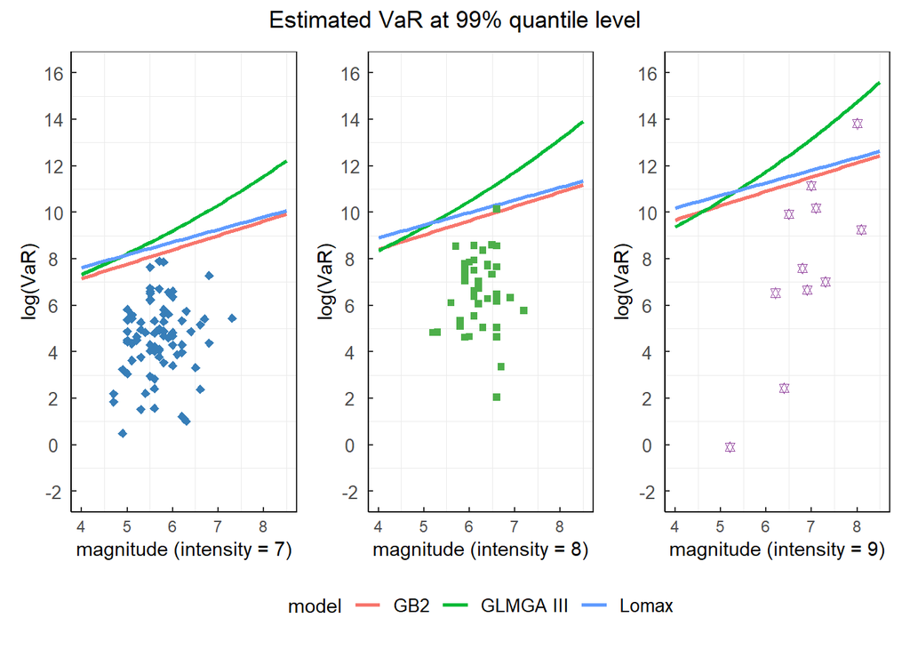

```r
# ==================================================================
x1 <- seq(4, 8.5, by = 0.1)
x2 <- seq(5, 11, by = 1)
dtpred <- expand.grid(x1 = x1, x2 = x2, model = c('GB2', 'GLMGA III', 'Lomax'))
Xpred <- model.matrix(~ x1 + x2, data = dtpred)
Xsigma <- model.matrix(~ x1, data = dtpred)
Xb <- model.matrix(~ x2, data = dtpred)


# GLMGA III
pars <- mlogmoyalGA3$par
sigma <- exp(Xsigma %*% pars[1:dim(Xsigma)[2]])
b <- exp(Xb %*%pars[(dim(Xsigma)[2]+1):(dim(Xsigma)[2] + dim(Xb)[2])])
a <- exp(pars[dim(Xsigma)[2] + dim(Xb)[2]+1])
VaR99.GLMGA3 <- qLMGA(0.99, sigma = sigma, a = a, b = b)

# GB2
pars <- mlGB2$par
lengthpar <- dim(Xpred)[2]
sigma <- exp(pars[lengthpar+3])  # shape
mu <- exp(Xpred %*% pars[1:lengthpar]) # scale
nu <- exp(pars[lengthpar+1])
tau <- exp(pars[lengthpar+2])
VaR99.GB2 <- qGB2(0.99, mu = mu, sigma = sigma, nu = nu, tau = tau)

# Lomax
pars <- mlpareto$par
lengthpar <- dim(Xpred)[2]
beta <- exp(pars[lengthpar+1])  #
sigma <- exp(Xpred%*%pars[1:lengthpar]) #
VaR99.Lomax <- 0
for (i in 1:nrow(dtpred)){
  VaR99.Lomax[i] <- qpareto2(0.99, shape = beta, scale = sigma[i])
}


dtpred <- data.table(dtpred)
dtpred$VaR99 <- VaR99.GB2
dtpred[, VaR99 := ifelse(model == 'GLMGA III', VaR99.GLMGA3, VaR99)]
dtpred[, VaR99 := ifelse(model == 'Lomax', VaR99.Lomax, VaR99)]

newtheme <- theme_bw() + theme(axis.line = element_line(colour = "black"),
                  axis.text.x = element_text(margin = margin(t = 0.25, unit = "cm")),
                  axis.text.y = element_text(margin = margin(r = 0.25, unit = "cm"),
                  size = 10,
                  vjust = 0.5,
                  hjust = 0.5),
                  panel.grid.major = element_blank(),
                  axis.ticks.length = unit(-0.1, "cm"),
                  plot.title = element_text(hjust = 0.5),
                  legend.position = 'top',
                  legend.text = element_text(size = 10))

col1 <- brewer.pal(4, name = "Accent")

dtplot <- dtpred[x2 == 7]
dtplot2 <- dtnew[intensity == 7]
p1 <- ggplot(dtplot, mapping = aes(x1, log(VaR99))) +
  geom_line(dtplot, mapping = aes(x1, log(VaR99),
                                  group = model,
                                  col = model), size = 1) +
  xlab("magnitude (intensity = 7)") +
  ylab("log(VaR)") +
  newtheme +
  geom_point(data = dtplot2,
             aes(magnitude, log(ynew)),
             shape = 23,
             col = '#377EB8', fill = '#377EB8') +
  scale_y_continuous(limits = c(-2, 16),
                     breaks = seq(-2, 16, by = 2))

dtplot <- dtpred[x2 == 8]
dtplot2 <- dtnew[intensity == 8]
p2 <- ggplot(dtplot, mapping = aes(x1, log(VaR99))) +
  geom_line(dtplot, mapping = aes(x1, log(VaR99), group = model, col = model), size = 1) +
  xlab("magnitude (intensity = 8)") +
  ylab("log(VaR)") +
  newtheme +
  geom_point(data = dtplot2,
             aes(magnitude, log(ynew)),
             shape = 15,
             fill = '#4DAF4A',
             col = '#4DAF4A') +
  scale_y_continuous(limits = c(-2, 16),
                     breaks = seq(-2, 16, by = 2))


dtplot <- dtpred[x2 == 9]
dtplot2 <- dtnew[intensity>=9]
p3 <- ggplot(dtplot, mapping = aes(x1, log(VaR99))) +
  geom_line(dtplot, mapping = aes(x1, log(VaR99), group = model, col = model), size = 1) +
  xlab("magnitude (intensity = 9)") +
  ylab("log(VaR)") +
  newtheme +
  geom_point(data = dtplot2,
             aes(magnitude, log(ynew)),
             shape = 11,
             fill = '#984EA3',
             col = '#984EA3') +
  scale_y_continuous(limits = c(-2, 16),
                     breaks = seq(-2, 16, by = 2))

p20 <- p1 + p2 + p3 & theme(legend.position = "bottom")
p20 <- p20 + plot_layout(guides = "collect") + plot_annotation(title = "Estimated VaR at 99% quantile level",
                                                               theme = theme(plot.title = element_text(hjust = 0.5)))
p20
```

```r
# ggsave("C:/坚果云同步/对外经济贸易大学 - 科研/0. Generalizing the log-Moyal distribution and regression models for heavy tailed loss data/合作文件 - 杨亮 - 文稿+代码/0. revised version/manuscript  - Astin/figures/fig_VaR_regression.eps",
#       p20, device = cairo_ps)
```